# COM747 Week 3 Seminar: Complete Solutions

Law of large numbers, power, the rundata tutorial, scientific notation and outliers

> **How to use this notebook.** All four Week 3 exercises, completed and commented line by line, plus the short note on the tilde. Put `rundata.csv` in the same folder. Where a sheet’s code is misleading or fails, an orange box explains the fix.

```r
library(pwr)      # install.packages("pwr")
```

# Exercise 1: The law of large numbers

## 1.1 The sheet’s code, with comments

```r
set.seed(52)                               # so your plots match these (not in the sheet)
population <- rnorm(1000, 52, 40)          # a "population" of 1000 exam scores: mean 52, SD 40
samplemeans <- vector(length = 100)        # empty vector to hold 100 sample means
sampleSDs   <- vector(length = 100)        # and 100 sample SDs

for (i in 1:100) {                         # repeat for i = 1, 2, ..., 100
  y <- sample(population, i * 10)          # draw a sample of size 10, 20, ..., 1000 (without replacement)
  samplemeans[i] <- mean(y)                # store this sample's mean
  sampleSDs[i]   <- sd(y)                  # and its standard deviation
}
```

## 1.2 Plots

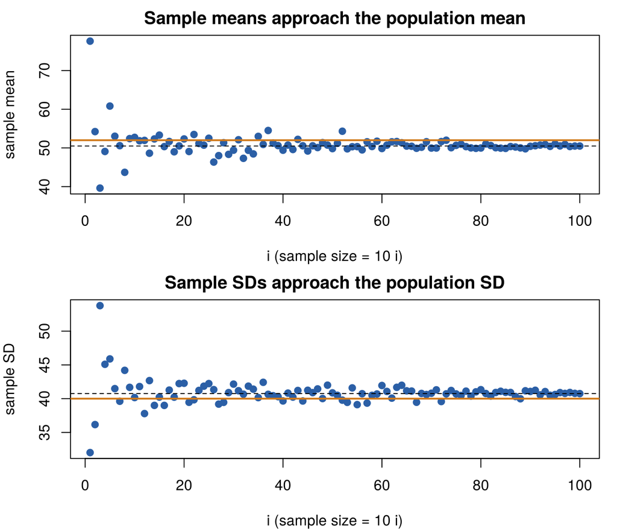

```r
par(mfrow = c(2, 1), mar = c(4, 4, 2, 1))
plot(samplemeans, pch = 19, col = "#2b5fa6", xlab = "i (sample size = 10 i)", ylab = "sample mean",
     main = "Sample means approach the population mean")
abline(h = 52, col = "#d0791a", lwd = 2)              # the true (theoretical) mean
abline(h = mean(population), lty = 2)                 # the mean of these 1000 numbers
plot(sampleSDs, pch = 19, col = "#2b5fa6", xlab = "i (sample size = 10 i)", ylab = "sample SD",
     main = "Sample SDs approach the population SD")
abline(h = 40, col = "#d0791a", lwd = 2)
abline(h = sd(population), lty = 2)
```

```r
par(mfrow = c(1, 1))
```

Small samples (left) scatter widely; large samples (right) settle down. The spread of the sample means shrinks like $\sigma/\sqrt{n}$: the **standard error**.

**A subtlety.** `sample(population, i * 10)` samples *without replacement* from only 1,000 numbers, so at i = 100 the “sample” is the whole population and its mean is exactly `mean(population)` (dashed line), not 52. The 1,000 numbers are themselves a sample from the N(52, 40) distribution. To see the law of large numbers for the true mean, sample from the distribution itself:

```r
set.seed(1)
n <- c(10, 50, 100, 500, 1000, 5000, 10000, 50000)
data.frame(n = n, sample_mean = round(sapply(n, function(k) mean(rnorm(k, 52, 40))), 2),
           standard_error = round(40 / sqrt(n), 2))
```

```
##       n sample_mean standard_error
## 1    10       57.29          12.65
## 2    50       56.11           5.66
## 3   100       49.72           4.00
## 4   500       51.66           1.79
## 5  1000       51.42           1.26
## 6  5000       51.89           0.57
## 7 10000       51.43           0.40
## 8 50000       51.92           0.18
```

## 1.3 Playing with the simulator

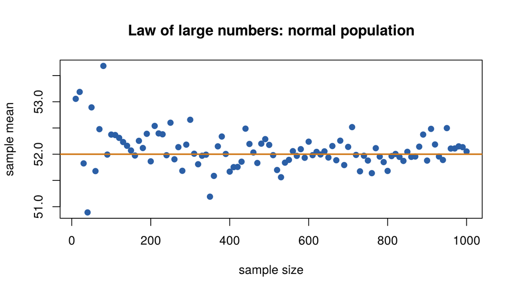

```r
lln <- function(pop_mean = 52, pop_sd = 40, steps = 100, step = 10, dist = c("normal", "skewed")) {
  dist <- match.arg(dist)
  sizes <- (1:steps) * step
  means <- sapply(sizes, function(k) mean(if (dist == "normal") rnorm(k, pop_mean, pop_sd) else rexp(k, 1 / pop_mean)))
  plot(sizes, means, pch = 19, col = "#2b5fa6", xlab = "sample size", ylab = "sample mean",
       main = paste("Law of large numbers:", dist, "population"))
  abline(h = pop_mean, col = "#d0791a", lwd = 2)
}
set.seed(2); lln(pop_sd = 5)            # small SD: means settle quickly
```

```r
set.seed(2); lln(dist = "skewed")       # still works for a skewed (exponential) population
```

[figure not shown]

# Exercise 2: Simulation, effect size and power

## 2.1 The simulation, commented

```r
set.seed(3)
samplesize <- 200                 # sample size of EACH group
meanX <- 50; meanY <- 51          # population means: a true difference of 1
sdX <- 5;    sdY <- 5             # population SDs
pvalues <- vector(length = 100)

effectSize <- abs(meanX - meanY) / sqrt(((sdX * sdX) + (sdY * sdY)) / 2)   # Cohen's d = difference / pooled SD
effectSize                        # 0.2: a "small" effect
```

```
## [1] 0.2
```

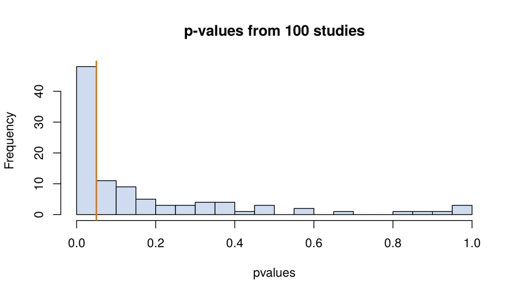

```r
for (i in 1:100) {                # 100 independent studies
  x <- rnorm(samplesize, meanX, sdX)      # each study samples both groups
  y <- rnorm(samplesize, meanY, sdY)
  p <- t.test(x, y)                       # Welch two-sample t-test
  pvalues[i] <- p$p.value
}
hist(pvalues, breaks = 20, col = "#cfdcf0", main = "p-values from 100 studies")
abline(v = 0.05, col = "#d0791a", lwd = 2)
```

```r
length(pvalues[pvalues < 0.05])   # studies that detected the (real) difference: about the power
```

```
## [1] 48
```

The sheet writes `t.test(x, y, PAIRED = FALSE)`. R is case-sensitive, so `PAIRED` isn’t the `paired` argument: it is silently ignored. The result is still an unpaired test only because that is the default. Write `paired = FALSE` if you mean it.

## 2.2 Manipulate the variables: power curves

```r
sim_power <- function(n, d, reps = 300) {
  mean(replicate(reps, t.test(rnorm(n, 0, 1), rnorm(n, d, 1))$p.value < 0.05))
}
set.seed(4)
grid <- expand.grid(n = c(10, 20, 50, 100, 200), d = c(0.2, 0.5, 0.8))
grid$power <- mapply(sim_power, grid$n, grid$d)
xtabs(power ~ n + d, grid)
```

```
##      d
## n            0.2        0.5        0.8
##   10  0.08333333 0.16333333 0.39000000
##   20  0.09000000 0.36000000 0.67000000
##   50  0.16333333 0.72333333 0.97666667
##   100 0.30000000 0.94000000 1.00000000
##   200 0.46666667 1.00000000 1.00000000
```

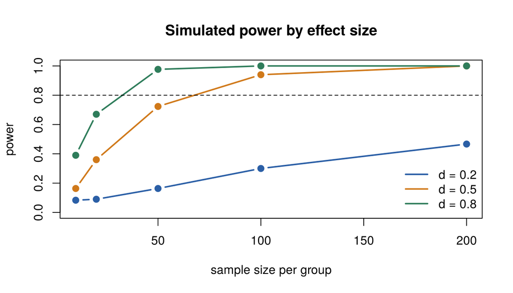

```r
cols <- c("#2b5fa6", "#d0791a", "#2f7d5b")
plot(NULL, xlim = c(10, 200), ylim = c(0, 1), xlab = "sample size per group", ylab = "power",
     main = "Simulated power by effect size")
for (j in seq_along(unique(grid$d))) { g <- grid[grid$d == unique(grid$d)[j], ]; lines(g$n, g$power, type = "b", col = cols[j], pch = 19, lwd = 2) }
abline(h = 0.8, lty = 2)
legend("bottomright", legend = paste("d =", unique(grid$d)), col = cols, lwd = 2, bty = "n")
```

Bigger effects and bigger samples both raise power. A small effect (d = 0.2) needs about 400 per group for 80% power.

## 2.3 R’s power functions

```r
power.t.test(power = 0.80, delta = 0.5, type = "two.sample")   # sd = 1 by default, so delta = d: n = 64 per group
```

```
##
##      Two-sample t test power calculation
##
##               n = 63.76576
##           delta = 0.5
##              sd = 1
##       sig.level = 0.05
##           power = 0.8
##     alternative = two.sided
##
## NOTE: n is number in *each* group
```

```r
power.t.test(n = 200, delta = 1, sd = 5)                        # the simulation above: power about 0.51
```

```
##
##      Two-sample t test power calculation
##
##               n = 200
##           delta = 1
##              sd = 5
##       sig.level = 0.05
##           power = 0.5140434
##     alternative = two.sided
##
## NOTE: n is number in *each* group
```

```r
pwr.t.test(n = 100, d = 0.5, sig.level = 0.05, type = "two.sample")   # power about 0.94
```

```
##
##      Two-sample t test power calculation
##
##               n = 100
##               d = 0.5
##       sig.level = 0.05
##           power = 0.9404272
##     alternative = two.sided
##
## NOTE: n is number in *each* group
```

```r
pwr.t.test(d = 0.2, power = 0.8, sig.level = 0.05)              # n about 394 per group
```

```
##
##      Two-sample t test power calculation
##
##               n = 393.4057
##               d = 0.2
##       sig.level = 0.05
##           power = 0.8
##     alternative = two.sided
##
## NOTE: n is number in *each* group
```

**Case study (Potts et al., 2022, ACE-III).** When a study compares cognitive scores between groups (dementia, mild cognitive impairment, controls), what sample size would it need to detect a small difference reliably? This is why power is planned *before* data collection.

## 2.4 The rundata tutorial

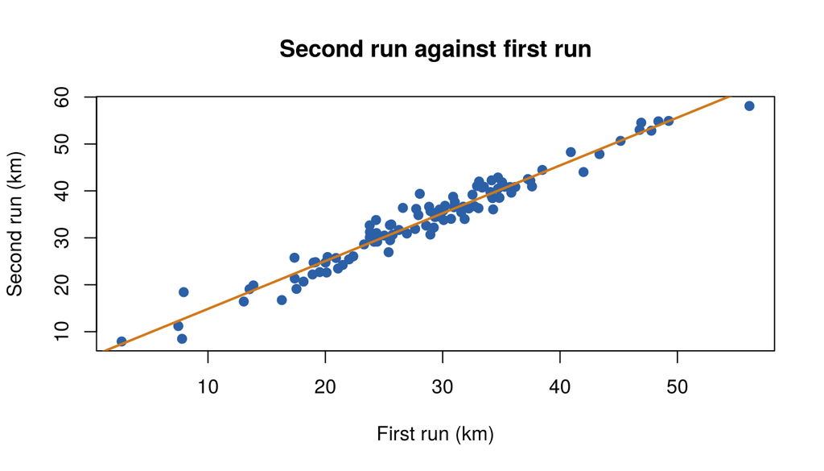

```r
rundata <- read.csv("rundata.csv")
plot(rundata$FirstRun, rundata$SecondRun, pch = 19, col = "#2b5fa6",
     xlab = "First run (km)", ylab = "Second run (km)")
reg1 <- lm(SecondRun ~ FirstRun, data = rundata)   # same as lm(rundata$SecondRun ~ rundata$FirstRun)
abline(reg1, col = "#d0791a", lwd = 2)
title("Second run against first run")
```

```r
coef(reg1)       # second run ≈ intercept + slope × first run
```

```
## (Intercept)    FirstRun
##    4.674700    1.018939
```

The sheet’s `title(“my title”)` uses curly quotes; use `title("my title")`. Using `data = rundata` inside `lm()` is also better practice: `predict()` then works on new data.

### Different graphs (statmethods.net)

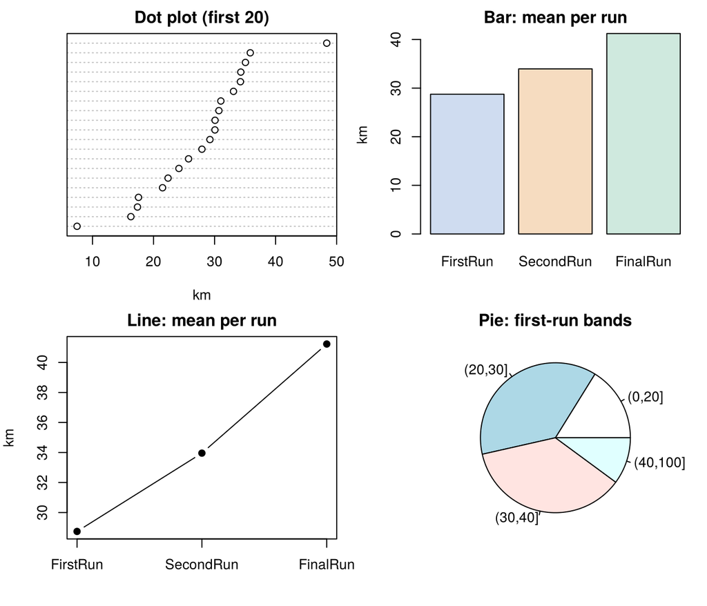

```r
par(mfrow = c(2, 2), mar = c(4, 4, 2, 1))
dotchart(sort(rundata$FirstRun[1:20]), main = "Dot plot (first 20)", xlab = "km")
barplot(colMeans(rundata), col = c("#cfdcf0", "#f6dcc0", "#cfe9de"), main = "Bar: mean per run", ylab = "km")
plot(colMeans(rundata), type = "b", pch = 19, xaxt = "n", main = "Line: mean per run", xlab = "", ylab = "km")
axis(1, at = 1:3, labels = names(rundata))
pie(table(cut(rundata$FirstRun, c(0, 20, 30, 40, 100))), main = "Pie: first-run bands")
```

```r
par(mfrow = c(1, 1))
```

### Correlation

```r
cor(rundata$FirstRun, rundata$SecondRun)        # r = 0.976
```

```
## [1] 0.9762012
```

```r
cor.test(rundata$FirstRun, rundata$SecondRun)   # significant: p < 2.2e-16
```

```
##
##  Pearson's product-moment correlation
##
## data:  rundata$FirstRun and rundata$SecondRun
## t = 44.333, df = 97, p-value < 2.2e-16
## alternative hypothesis: true correlation is not equal to 0
## 95 percent confidence interval:
##  0.9647003 0.9839856
## sample estimates:
##       cor
## 0.9762012
```

```r
round(cor(rundata), 3)                          # all pairs at once
```

```
##           FirstRun SecondRun FinalRun
## FirstRun     1.000     0.976    0.926
## SecondRun    0.976     1.000    0.961
## FinalRun     0.926     0.961    1.000
```

**Which runs correlate the most?** First and second (r = 0.976); runs further apart in time correlate less (first and final 0.926).

### New column and subsetting

```r
rundata$runDiff <- rundata$SecondRun - rundata$FirstRun     # improvement from run 1 to run 2

# How many ran more than 30 km in their first run?
y <- rundata$FirstRun[rundata$FirstRun > 30]
length(y)                                                   # 46
```

```
## [1] 46
```

```r
sum(rundata$FirstRun > 30)                                  # shorter: TRUE counts as 1
```

```
## [1] 46
```

```r
# How many did better in their second run?
length(rundata$runDiff[rundata$runDiff >= 1])               # the sheet's version: improved by at least 1 km (97)
```

```
## [1] 97
```

```r
sum(rundata$runDiff > 0)                                    # strictly better at all (99)
```

```
## [1] 99
```

```r
sum(rundata$runDiff < 0)                                    # worse (0)
```

```
## [1] 0
```

`runDiff >= 1` counts runners who improved by **at least 1 km**, not everyone who did better. “Did better” is `runDiff > 0`. Here every runner improved.

### Paired t-test

```r
t.test(rundata$FirstRun, rundata$SecondRun, paired = TRUE)
```

```
##
##  Paired t-test
##
## data:  rundata$FirstRun and rundata$SecondRun
## t = -23.986, df = 98, p-value < 2.2e-16
## alternative hypothesis: true mean difference is not equal to 0
## 95 percent confidence interval:
##  -5.650776 -4.787204
## sample estimates:
## mean difference
##        -5.21899
```

The same runners ran twice, so the test is **paired**: it tests whether the mean of the differences is 0. p is far below 0.05, so the second run was significantly longer, by about 5.2 km on average (95% CI in the output).